# Homework 6

Ryan Richardson

08/12/2020

## Question 1

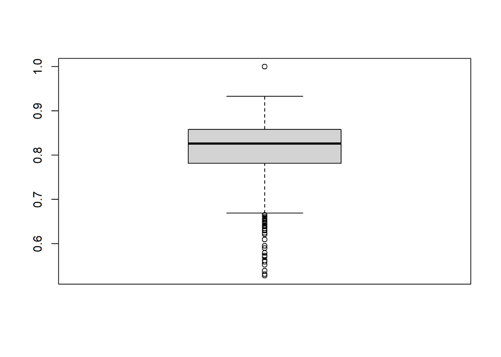

```r
scorePlot = boxplot(demo$Prof_Score)
```

```r
scoreOutliers = scorePlot$out
scoreBreaks = scorePlot$stats

outlierMin = min(scoreOutliers)
outlierMax = max(scoreOutliers)
```

### IQR

```r
minRange = c(outlierMin, first(scoreBreaks))
maxRange = c(last(scoreBreaks), outlierMax)
outlierCount = length(scoreOutliers)

minRange
```

```
## [1] 0.5277778 0.6687500
```

```r
maxRange
```

```
## [1] 0.9333333 1.0000000
```

```r
outlierCount
```

```
## [1] 32
```

Outliers range from [0.5278, 0.6688) and (0.9333,1] There are a total of 32 outliers using IQR as our detection method.

### Standard Deviation

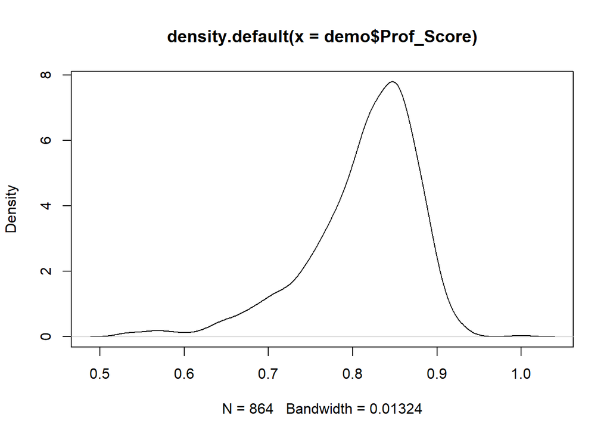

```r
plot(density(demo$Prof_Score))
```

```r
scoreSd = sd(demo$Prof_Score)
scoreMean = mean(demo$Prof_Score)

upper = scoreMean + (3*scoreSd)
lower = scoreMean - (3*scoreSd)

upperOut = demo$Prof_Score > upper
lowerOut = demo$Prof_Score < lower


sdUpperOutliers = demo$Prof_Score[upperOut]
sdLowerOutliers = demo$Prof_Score[lowerOut]
```

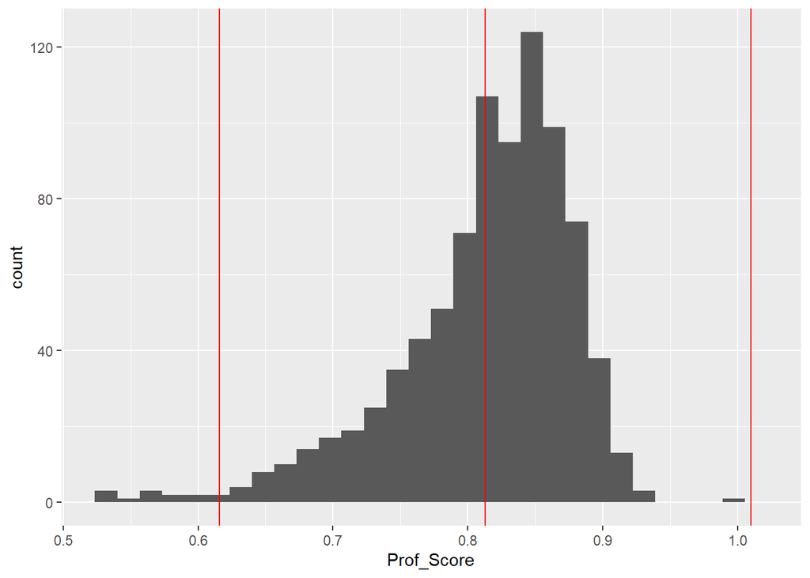

```r
ggplot(demo, aes(x=Prof_Score)) +
  geom_histogram() +
  geom_vline(xintercept = lower, color='red') +
  geom_vline(xintercept = upper, color='red') +
  geom_vline(xintercept = scoreMean, color='red')
```

```r
sdOutliers = c(sdLowerOutliers, sdUpperOutliers)
sdOutliers
```

```
##  [1] 0.5315789 0.5523810 0.5388889 0.5590909 0.6095238 0.5625000 0.5277778
##  [8] 0.5705882 0.5736842 0.5952381 0.5789474 0.5904762
```

```r
sdOutlierRange = c(min(sdOutliers), max(sdOutliers))
sdOutlierRange
```

```
## [1] 0.5277778 0.6095238
```

```r
length(sdOutliers)
```

```
## [1] 12
```

Using the Standard Deviation to catch outliers resulted in only 12 outliers being found between [0.528, 0.61]

The upper range of the outliers ended up being larger a score greater than 100%, which would have been impossilbe to achieve in this case, meaning there were no outliers found in the upper range, this is likely due to the heavily skewed distribution of scores.

### Inferential Statistics

```r
scores = demo$Prof_Score
gTest = grubbs.test(scores)
gOut = c()
while (gTest$p.value < 0.05)
{
  altValue = gTest$alternative
  altValue = as.numeric(strsplit(altValue," ")[[1]][3])
  gOut = append(gOut, altValue)
  scores = scores[!scores %in% altValue]
  gTest = grubbs.test(scores)
}

gRange = c(min(gOut), max(gOut))
gRange
```

```
## [1] 0.5277778 0.5789474
```

```r
length(gOut)
```

```
## [1] 9
```

Using Grubbs test for each value in the list, we end up with 9 outliers between [0.5278, 0.5789]. Grubbs test also missed the outlier at 1.0 due to taking out the smallest values first.

I think that if outliers are to be removed then the IQR method is the one to use. It’s the only method that accurately compensated for the outliers at the high end of the distribution, and was the least affected by the extremely skewed dataset. That said, the outliers themselves were never so far out of the range of possibility that they needed to be removed. It’s not unreasonable for some students to receive a 50% or for some to receive a 100%, so if I was able to, I would probably choose not to remove any outliers at all.

## Question 2

NAs appear only in Image_Quality and Smile. with a total of 3396 total records with NA values where 277 of those records have an NA in both Image_Quality and Smile.

```r
missingValuesByColumn = colSums(is.na(df))
```

```r
df$Image_QualityNA = as.factor(ifelse(is.na(df$Image_Quality),1,0))
df$SmileNA = as.factor(ifelse(is.na(df$Smile),1,0))

rForestImage = randomForest(Image_QualityNA ~ ., data = df[-c(5,10,13)])
rForestImage
```

```
##
## Call:
##  randomForest(formula = Image_QualityNA ~ ., data = df[-c(5, 10,      13)])
##                Type of random forest: classification
##                      Number of trees: 500
## No. of variables tried at each split: 3
##
##         OOB estimate of  error rate: 8.85%
## Confusion matrix:
##      0  1 class.error
## 0 7943 46 0.005757917
## 1  732 66 0.917293233
```

```r
rForestSmile = randomForest(SmileNA ~ ., data = df[-c(5,10,12)])
rForestSmile
```

```
##
## Call:
##  randomForest(formula = SmileNA ~ ., data = df[-c(5, 10, 12)])
##                Type of random forest: classification
##                      Number of trees: 500
## No. of variables tried at each split: 3
##
##         OOB estimate of  error rate: 33.17%
## Confusion matrix:
##      0  1 class.error
## 0 5838 74  0.01251691
## 1 2841 34  0.98817391
```

```r
df = df[-c(12,13)]
dfListDelete = df[complete.cases(df),]
imputeModel = mice(df, maxit=0)
imputePredictions = imputeModel$predictorMatrix
dfMultipleImpute = mice(df, maxit=5, predictorMatrix = imputePredictions, method = imputeModel$method, print=FALSE)
dfImputeComplete = complete(dfMultipleImpute,1)

summary(glm(Area~., data = dfListDelete))
```

```
##
## Call:
## glm(formula = Area ~ ., data = dfListDelete)
##
## Deviance Residuals:
##     Min       1Q   Median       3Q      Max
## -153151   -25364    -9754     8395  1443587
##
## Coefficients:
##                     Estimate Std. Error t value Pr(>|t|)
## (Intercept)            43769      12857   3.404 0.000668 ***
## Gendermale              7090       2448   2.896 0.003790 **
## Genderunknown          57567      10593   5.435 5.74e-08 ***
## Adult                  -4571       4463  -1.024 0.305859
## Face_Angle              1131       2373   0.476 0.633767
## Image_Color             3471       2142   1.621 0.105144
## Image_Qualitygood      24091       2186  11.018  < 2e-16 ***
## Image_Type              6051       3415   1.772 0.076460 .
## Contextauthor         -23080       9813  -2.352 0.018706 *
## Contextcover           68235       5370  12.706  < 2e-16 ***
## Contextfeature        -16050       2663  -6.026 1.79e-09 ***
## Multiface             -25740       2169 -11.867  < 2e-16 ***
## Raceasian              -4762      12134  -0.392 0.694735
## Raceblack             -10334      11869  -0.871 0.383943
## Racepacificislander   -11449      16079  -0.712 0.476464
## Raceunknown             7345      13836   0.531 0.595534
## Racewhite              -8860      11234  -0.789 0.430366
## Smile                  -4582       2204  -2.079 0.037630 *
## ---
## Signif. codes:  0 '***' 0.001 '**' 0.01 '*' 0.05 '.' 0.1 ' ' 1
##
## (Dispersion parameter for gaussian family taken to be 5856141474)
##
##     Null deviance: 3.5574e+13  on 5390  degrees of freedom
## Residual deviance: 3.1465e+13  on 5373  degrees of freedom
## AIC: 136567
##
## Number of Fisher Scoring iterations: 2
```

```r
summary(glm(Area~., data = dfImputeComplete))
```

```
##
## Call:
## glm(formula = Area ~ ., data = dfImputeComplete)
##
## Deviance Residuals:
##     Min       1Q   Median       3Q      Max
## -155789   -26514   -10507     7431  1467127
##
## Coefficients:
##                      Estimate Std. Error t value Pr(>|t|)
## (Intercept)          27399.64   10378.51   2.640 0.008304 **
## Gendermale            7506.57    1920.44   3.909 9.35e-05 ***
## Genderunknown        68722.32    8739.55   7.863 4.18e-15 ***
## Adult                 1092.42    3383.04   0.323 0.746771
## Face_Angle            1299.11    1855.14   0.700 0.483773
## Image_Color           5720.04    1690.39   3.384 0.000718 ***
## Image_Qualitygood    24138.67    1718.44  14.047  < 2e-16 ***
## Image_Type            8942.65    2589.81   3.453 0.000557 ***
## Contextauthor       -22754.86    5937.99  -3.832 0.000128 ***
## Contextcover         54620.14    4413.39  12.376  < 2e-16 ***
## Contextfeature      -18976.02    1968.09  -9.642  < 2e-16 ***
## Multiface           -24154.10    1710.92 -14.118  < 2e-16 ***
## Raceasian             4462.34    9890.51   0.451 0.651875
## Raceblack            -3339.83    9664.97  -0.346 0.729681
## Racepacificislander  -9652.97   12798.53  -0.754 0.450734
## Raceunknown           8595.27   11118.51   0.773 0.439508
## Racewhite              -55.36    9187.02  -0.006 0.995192
## Smile                -3360.49    1721.11  -1.953 0.050909 .
## ---
## Signif. codes:  0 '***' 0.001 '**' 0.01 '*' 0.05 '.' 0.1 ' ' 1
##
## (Dispersion parameter for gaussian family taken to be 5918710966)
##
##     Null deviance: 5.7620e+13  on 8786  degrees of freedom
## Residual deviance: 5.1901e+13  on 8769  degrees of freedom
## AIC: 222676
##
## Number of Fisher Scoring iterations: 2
```

Looking at the two models, the first with Listwise Deletion and the second with Imputed Data, the first model appears to better fit the data based on its lower AIC value. This model also has much lower deviance across the board compared to the imputed model, which is reflected in its lowered AIC. In this case, it seems to be the correct choice to use listwise deletion to remove all records with missing values instead of attempting to impute them.